# Tugas Pertemuan 3

Qurrota A’yunina | M0401241049

## Pengantar

Dalam pemodelan deret waktu, sering kali efek dari suatu kejadian (variabel X) terhadap target observasi (variabel Y) tidak terjadi secara instan, melainkan membutuhkan jeda waktu atau **Lag**.

Secara umum, terdapat tiga pendekatan utama untuk memodelkan efek jeda waktu ini:

1. **Distributed Lag Model (DLM):** Variabel dependen (Y) dipengaruhi oleh variabel independen saat ini dan masa lalu ($X_t, X_{t-1}, X_{t-2}$, dst).

2. **Autoregressive Model (AR):** Variabel dependen (Y) dipengaruhi oleh variabel independen saat ini ($X_t$) dan nilai dirinya sendiri di masa lalu ($Y_{t-1}, Y_{t-2}$, dst).

3. **Autoregressive Distributed Lag (ARDL):** Model gabungan di mana Y dipengaruhi oleh X saat ini, X masa lalu, dan Y masa lalu.

## 1. Persiapan Data

### *Packages*

```r
# Mengaktifkan library yang dibutuhkan

library(dLagM)
library(dynlm)
library(MLmetrics)
library(lmtest)
library(car)
library(readxl)
```

### Impor & Pembagian Data

Kita akan menggunakan data simulasi untuk melatih pemodelan. Data dibagi menjadi data Training (untuk membentuk model) dan data Testing (untuk menguji akurasi ramalan).

```r
# Impor Data
data <- read_excel("C://Users//USER//OneDrive//ドキュメント//MPDW 1//mpdw//Pertemuan 3//data AQI dan NO2.xlsx")

# Membagi data (15 observasi pertama untuk training, 5 observasi terakhir untuk testing)
train <- data[1:15,]
test <- data[16:20,]

# Mengubah format data menjadi objek Time Series (ts)
train.ts <- ts(train)
test.ts <- ts(test)
data.ts <- ts(data)
```

## 2. Model Koyck

Model Koyck mengatasi masalah infinite distributed lag (pengaruh masa lalu yang tak terhingga) dengan mengasumsikan bahwa semakin jauh jarak lag, semakin kecil pengaruhnya.

Melalui transformasi aljabar, efek masa lalu dari X yang sangat panjang diringkas ke dalam satu variabel saja, yaitu $Y_{t-1}$. Bentuk persamaannya menjadi:

$$Y_t=a(1-\lambda)+\beta_0X_t+\lambda
Y_{t-1}+V_t$$
Catatan: $V_t$ adalah error term gabungan. Pada hasil ringkasan model (estimasi), $V_t$ tidak ditampilkan karena nilai harapannya diasumsikan nol.

### Pemodelan

Pemodelan ini menggunakan fungsi `koyckDlm()`.

```r
# Membangun Model Koyck
model.koyck <- koyckDlm(x = train$no2, y = train$AQI)
summary(model.koyck)
```

```
##
## Call:
## "Y ~ (Intercept) + Y.1 + X.t"
##
## Residuals:
##     Min      1Q  Median      3Q     Max
## -1.2913 -0.4216 -0.2364  0.6974  1.4998
##
## Coefficients:
##              Estimate Std. Error t value Pr(>|t|)
## (Intercept)   18.9780     4.5610   4.161 0.001587 **
## Y.1            0.6551     0.1283   5.104 0.000342 ***
## X.t         -222.1309    61.9270  -3.587 0.004266 **
## ---
## Signif. codes:  0 '***' 0.001 '**' 0.01 '*' 0.05 '.' 0.1 ' ' 1
##
## Residual standard error: 0.9179 on 11 degrees of freedom
## Multiple R-Squared: 0.7852,  Adjusted R-squared: 0.7462
## Wald test: 21.22 on 2 and 11 DF,  p-value: 0.0001675
##
## Diagnostic tests:
## NULL
##
##                             alpha      beta       phi
## Geometric coefficients:  55.01986 -222.1309 0.6550702
```

**Interpretasi:** Jika *P-value* dari peubah $X_t$ dan $Y_{t-1}$ $< 0.05$ (masing-masing sebesar $0.004266$ dan $0.000342$), artinya kedua peubah tersebut berpengaruh signifikan terhadap $Y_t$ pada taraf nyata 5%. Koefisien pada $Y_{t-1}$ mewakili parameter $\phi$ (atau $\lambda$) yaitu tingkat keberlanjutan atau penurunan pengaruh lag dari variabel respon ($0.6551$).

**Persamaan:**

$$\hat{Y}_t = 18.9780 + 0.6551Y_{t-1} -
222.1309X_t$$

### Peramalan

```r
# Meramalkan 5 periode ke depan
fore.koyck <- forecast(model = model.koyck, x = test$no2, h = 5)
fore.koyck
```

```
## $forecasts
## [1] 29.35090 29.87815 29.10835 26.89412 24.10542
##
## $call
## forecast.koyckDlm(model = model.koyck, x = test$no2, h = 5)
##
## attr(,"class")
## [1] "forecast.koyckDlm" "dLagM"
```

```r
# Cek Akurasi (MAPE) pada data testing
mape.koyck <- MAPE(fore.koyck$forecasts, test$AQI)
cat("MAPE Model Koyck:", mape.koyck, "\n")
```

```
## MAPE Model Koyck: 0.03861867
```

## 3. Regression with Distributed Lag (DLM)

Berbeda dengan Koyck, pemodelan DLM membatasi secara spesifik berapa periode memori masa lalu yang dilibatkan. Batasan ini direpresentasikan dengan parameter $q$.

$$Y_t=\alpha+\beta_0X_t+\beta_1X_{t-1}+…+\beta_qX_{t-q}+e_t$$

### Pemodelan (Lag = 2)

Fungsi yang digunakan adalah `dlm()`. Parameter `q = 2` berarti kita memasukkan $X_t, X_{t-1}$, dan $X_{t-2}$.

```r
model.dlm <- dlm(x = train$no2, y = train$AQI, q = 2)
summary(model.dlm)
```

```
##
## Call:
## lm(formula = model.formula, data = design)
##
## Residuals:
##     Min      1Q  Median      3Q     Max
## -1.3565 -0.3630 -0.1399  0.5291  0.9288
##
## Coefficients:
##             Estimate Std. Error t value Pr(>|t|)
## (Intercept)   47.531      3.041  15.631 7.89e-08 ***
## x.t          208.165    173.932   1.197   0.2620
## x.1          -92.303    310.717  -0.297   0.7732
## x.2         -578.658    206.424  -2.803   0.0206 *
## ---
## Signif. codes:  0 '***' 0.001 '**' 0.01 '*' 0.05 '.' 0.1 ' ' 1
##
## Residual standard error: 0.7452 on 9 degrees of freedom
## Multiple R-squared:  0.8692, Adjusted R-squared:  0.8256
## F-statistic: 19.94 on 3 and 9 DF,  p-value: 0.0002588
##
## AIC and BIC values for the model:
##      AIC      BIC
## 1 34.465 37.28975
```

### Penentuan *Lag* Optimum

Untuk menghindari coba-coba, kita bisa mencari nilai $q$ terbaik berdasarkan nilai *Akaike Information Criterion (AIC)* terkecil menggunakan fungsi `finiteDLMauto()`.

```r
finiteDLMauto(formula = AQI ~ no2,
              data = data.frame(train), q.min = 1, q.max = 10,
              model.type = "dlm", error.type = "AIC", trace = TRUE)
```

```
##    q - k    MASE      AIC      BIC     GMRAE    MBRAE R.Adj.Sq Ljung-Box
## 7      7 0.00000     -Inf     -Inf   0.00000  0.07143      NaN       NaN
## 8      8 0.00000     -Inf     -Inf   0.00000  0.08333      NaN       NaN
## 9      9 0.00000     -Inf     -Inf   0.00000  0.10000      NaN       NaN
## 10    10 0.00000     -Inf     -Inf   0.00000  0.12500      NaN       NaN
## 6      6 0.18103 20.80846 22.58348   1.59476  0.17429  0.84387 0.1357112
## 4      4 0.39942 25.43135 28.21662 290.14200  0.34206  0.90134 0.1014024
## 5      5 0.36610 26.76636 29.18704  49.10449  0.29135  0.86030 0.1314859
## 3      3 0.51909 32.33355 35.24299 139.91163  0.31163  0.84043 0.9477665
## 2      2 0.54968 34.46500 37.28975 116.29201  0.22472  0.82560 0.4613922
## 1      1 0.80426 49.35152 51.90775  76.37968 32.57292  0.56953 0.8999904
```

```r
# Membangun ulang DLM dengan Lag Optimum (q=6)
model.dlm.opt <- dlm(x = train$no2, y = train$AQI, q = 6)
summary(model.dlm.opt)
```

```
##
## Call:
## lm(formula = model.formula, data = design)
##
## Residuals:
##        1        2        3        4        5        6        7        8
##  0.54383 -0.56437 -0.09427  0.18499 -0.03889  0.06558  0.03496 -0.21893
##        9
##  0.08710
##
## Coefficients:
##             Estimate Std. Error t value Pr(>|t|)
## (Intercept)    34.10      20.15   1.692    0.340
## x.t           335.43     305.36   1.098    0.470
## x.1          -368.00     425.83  -0.864    0.546
## x.2          -298.84     448.42  -0.666    0.626
## x.3           141.96     433.38   0.328    0.798
## x.4           -77.91     451.74  -0.172    0.891
## x.5          -556.06     515.33  -1.079    0.476
## x.6           645.16     554.95   1.163    0.452
##
## Residual standard error: 0.8485 on 1 degrees of freedom
## Multiple R-squared:  0.9805, Adjusted R-squared:  0.8439
## F-statistic: 7.177 on 7 and 1 DF,  p-value: 0.28
##
## AIC and BIC values for the model:
##        AIC      BIC
## 1 20.80846 22.58348
```

```r
# Peramalan model DLM Optimum
fore.dlm.opt <- forecast(model = model.dlm.opt, x = test$no2, h = 5)
mape.dlm.opt <- MAPE(fore.dlm.opt$forecasts, test$AQI)
cat("MAPE Model DLM Optimum:", mape.dlm.opt, "\n")
```

```
## MAPE Model DLM Optimum: 0.05047257
```

## 4. Autoregressive Distributed Lag (ARDL)

Model ARDL menggabungkan pengaruh dari peubah independen masa lalu dan peubah dependen masa lalu.

**Perhatian Notasi:**

Pada *package* `dLagM` (khusus fungsi `ardlDlm`), aturannya adalah:

- $p$ = panjang *lag* peubah independen ($X$).
- $q$ = panjang *lag* peubah dependen ($Y$).

### Pemodelan

```r
# Model ARDL dengan lag X = 1 dan lag Y = 1
model.ardl <- ardlDlm(formula = AQI ~ no2, data = train, p = 1, q = 1)
summary(model.ardl)
```

```
##
## Time series regression with "ts" data:
## Start = 2, End = 15
##
## Call:
## dynlm(formula = as.formula(model.text), data = data)
##
## Residuals:
##     Min      1Q  Median      3Q     Max
## -1.2440 -0.4365 -0.1538  0.5118  1.1497
##
## Coefficients:
##              Estimate Std. Error t value Pr(>|t|)
## (Intercept)   24.4534     5.8099   4.209  0.00180 **
## no2.t        116.6549   196.0493   0.595  0.56505
## no2.1       -372.6624   224.5813  -1.659  0.12803
## AQI.1          0.5124     0.1478   3.468  0.00605 **
## ---
## Signif. codes:  0 '***' 0.001 '**' 0.01 '*' 0.05 '.' 0.1 ' ' 1
##
## Residual standard error: 0.8448 on 10 degrees of freedom
## Multiple R-squared:  0.8346, Adjusted R-squared:  0.785
## F-statistic: 16.82 on 3 and 10 DF,  p-value: 0.000311
```

### *Lag* Optimum ARDL

Kita bisa mencari kombinasi $p$ dan $q$ terbaik dengan fungsi `ardlBoundOrders()`.

```r
model.ardl.opt <- ardlBoundOrders(data = data.frame(data), ic = "AIC", formula = AQI ~ no2)

# Menarik kombinasi lag dengan AIC terkecil
min_p <- c()
for(i in 1:6){
  min_p[i] <- min(model.ardl.opt$Stat.table[[i]])
}
q_opt <- which(min_p == min(min_p, na.rm = TRUE))
p_opt <- which(model.ardl.opt$Stat.table[[q_opt]] == min(model.ardl.opt$Stat.table[[q_opt]], na.rm = TRUE))

data.frame("Lag_Y_opt(q)" = q_opt, "Lag_X_opt(p)" = p_opt, "AIC" = model.ardl.opt$min.Stat)
```

```
##   Lag_Y_opt.q. Lag_X_opt.p.      AIC
## 1            6           14 133.8784
```

```r
# Peramalan ARDL awal (p=1, q=1)
fore.ardl <- forecast(model = model.ardl, x = test$no2, h = 5)
mape.ardl <- MAPE(fore.ardl$forecasts, test$AQI)
cat("MAPE Model ARDL (1,1):", mape.ardl, "\n")
```

```
## MAPE Model ARDL (1,1): 0.051747
```

## 5. Pendekatan dengan Library `dynlm` dan Uji Asumsi

Pemodelan juga dapat dilakukan secara manual menggunakan library `dynlm`. Keunggulannya adalah kemudahan dalam memanggil fungsi uji asumsi sisaan (karena format outputnya setara dengan regresi linier standar `lm`).

Gunakan fungsi `L()` untuk memanggil nilai masa lalu (*lag*).

```r
# Sama dengan DLM (q=1)
cons_lm1 <- dynlm(AQI ~ no2 + L(no2), data = train.ts)

# Setara dengan Model Autoregressive Murni (Hanya melibatkan Xt dan Yt-1)
cons_lm2 <- dynlm(AQI ~ no2 + L(AQI), data = train.ts)

# Sama dengan ARDL (p=1, q=1)
cons_lm3 <- dynlm(AQI ~ no2 + L(no2) + L(AQI), data = train.ts)
```

### Uji Asumsi Model (Contoh pada cons_lm1)

### 1. Uji Autokorelasi (Durbin-Watson)

H0: Tidak ada autokorelasi

```r
dwtest(cons_lm1)
```

```
##
##  Durbin-Watson test
##
## data:  cons_lm1
## DW = 1.6834, p-value = 0.1134
## alternative hypothesis: true autocorrelation is greater than 0
```

### 2. Uji Heteroskedastisitas (Breusch-Pagan)

H0: Ragam sisaan homogen

```r
bptest(cons_lm1)
```

```
##
##  studentized Breusch-Pagan test
##
## data:  cons_lm1
## BP = 0.25989, df = 2, p-value = 0.8781
```

### 3. Uji Normalitas (Shapiro-Wilk)

H0: Sisaan berdistribusi normal

```r
shapiro.test(residuals(cons_lm1))
```

```
##
##  Shapiro-Wilk normality test
##
## data:  residuals(cons_lm1)
## W = 0.95765, p-value = 0.6843
```

(Catatan: Tolak H0 jika p-value < 0.05)

## 6. Perbandingan Performa Model

Mari kita bandingkan akurasi peramalan berdasarkan MAPE dan memvisualisasikannya.

### Akurasi

```r
# Ringkasan Akurasi
akurasi <- matrix(c(mape.koyck, mape.dlm.opt, mape.ardl))
row.names(akurasi) <- c("Koyck", "DLM Optimum", "ARDL (1,1)")
colnames(akurasi) <- c("MAPE")
print(akurasi)
```

```
##                   MAPE
## Koyck       0.03861867
## DLM Optimum 0.05047257
## ARDL (1,1)  0.05174700
```

```r
# 1. Hitung Deviance dari masing-masing model
dev.koyck <- deviance(model.koyck$model)
dev.dlm   <- deviance(model.dlm$model)   # Sesuaikan dengan nama variabel model DLM kamu
dev.ardl  <- deviance(model.ardl$model)  # Sesuaikan dengan nama variabel model ARDL kamu

# 2. Buat matriks gabungan (MAPE dan Deviance)
akurasi <- matrix(
  c(mape.koyck, mape.dlm.opt, mape.ardl,
    dev.koyck,  dev.dlm,      dev.ardl),
  nrow = 3,
  ncol = 2
)

# 3. Beri nama baris dan kolom
row.names(akurasi) <- c("Koyck", "DLM Optimum", "ARDL (1,1)")
colnames(akurasi)  <- c("MAPE", "Deviance")

# 4. Tampilkan hasil
print(akurasi)
```

[output not shown]

### Visualisasi Aktual vs Peramalan

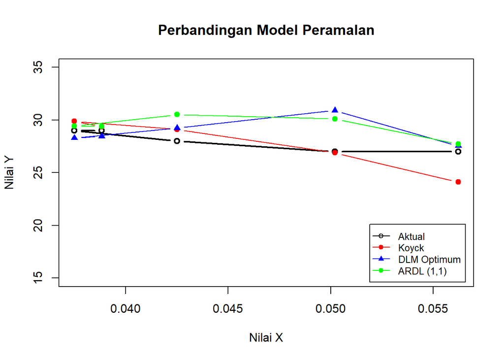

```r
par(mfrow=c(1,1))
plot(test$no2, test$AQI, type="b", col="black", ylim=c(15,35), lwd=2,
     ylab="Nilai Y", xlab="Nilai X", main="Perbandingan Model Peramalan")

lines(test$no2, fore.koyck$forecasts, col="red", type="b", pch=19)
lines(test$no2, fore.dlm.opt$forecasts, col="blue", type="b", pch=17)
lines(test$no2, fore.ardl$forecasts, col="green", type="b", pch=19)

legend("bottomright", legend=c("Aktual", "Koyck", "DLM Optimum", "ARDL (1,1)"),
       col=c("black","red","blue","green"), lty=1, pch=c(1,19,17,19), cex=0.8, inset=0.02)
```

## Interpretasi Hasil Perbandingan Model

### A. Nilai Akurasi Peramalan (MAPE)

- **Model Koyck:** Nilai MAPE sebesar **0,0386 (3,86%)**. Artinya, rata-rata kesalahan mutlak peramalan model Koyck sangat kecil, yaitu kurang dari 5%.
- **Model DLM Optimum:** Nilai MAPE sebesar **0,0505 (5,05%)**.
- **Model ARDL (1,1):** Nilai MAPE sebesar **0,0517 (5,17%)**.

> **Catatan Akurasi:** Kriteria kemampuan peramalan berdasarkan nilai MAPE:
> - $< 10\%$: Sangat baik (sangat akurat)
> - $10\% - 20\%$: Baik
> - $20\% - 50\%$: Layak
> - $> 50\%$: Buruk

> Ketiga model memiliki nilai MAPE $< 10\%$, yang menandakan seluruh model memiliki performa peramalan yang **sangat baik**. Namun, **Model Koyck** menghasilkan nilai MAPE paling rendah (3,86%).

### C. Visualisasi Grafik Perbandingan

Berdasarkan plot **Perbandingan Model Peramalan**:

- Line plot berwarna **merah (Koyck)** cenderung mengikuti pergerakan data **aktual (hitam)** secara lebih dekat dibandingkan model **DLM Optimum (biru)** dan **ARDL (1,1) (hijau)**.
- Model DLM dan ARDL terlihat *overestimate* (memprediksi nilai Y/AQI lebih tinggi dari nilai aktualnya) pada rentang nilai X tertentu.

## Kesimpulan

1. **Model Terbaik:** Dari ketiga metode regresi dengan peubah lag yang diuji (Koyck, DLM Optimum, dan ARDL 1,1), **Model Koyck** adalah model terbaik untuk memprediksi nilai AQI ($Y$) berdasarkan polutan $X$ ($\text{NO}_2$).
2. **Alasan Pemilihan:**
- Memiliki nilai kesalahan peramalan terkecil dengan **MAPE 3,86%**.
- Grafik peramalan model Koyck paling mendekati dan konsisten mengikuti pola data aktualnya.